# Part II - (Loan dataset EDA)

## by (Augustine Ugbeda)

## Investigation Overview

I am interested in how employment status and debtToIncome ratio associates with various variables in the dataset.and what features affect Annual Percentage Rate (APR)

January has the highest number of loans listed as expected from starting of new year , whereas april sees the least number of loans listed.

The distribution of APR looks multimodal. A small peak centered at 0.1, a large peak centered at 0.2. There is also a small peak centered 0.3. Additionally, there is a very shape peak between 0.35 and 0.36. Only very few loans have APR greater than 0.43.

The borrower APR decreases with the increasingly better rating. Borrowers with the best Prosper ratings have the lowest APR. It means that the Prosper rating has a strong effect on borrower APR.

## Dataset Overview

Original dataset contains 113,937 loans with 81 variables on each loan which was reduced to 84853 loans with 21 columns, including loan amount, borrower rate (or interest rate), current loan status, borrower income, and many others.

## Distribution of borrower Apr

APR distribution is multimodal.Only very few loans have APR greater than 0.4.we have a very shape peak between 0.35 and 0.36 and small peaks centered around 0.1, 0.2, 0.3 respectively.

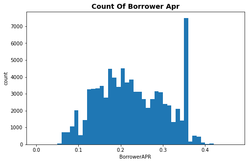

## BoxPlot of Loan status and Borrow rate

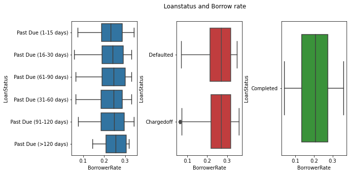

## Loan frequecy by month

January has the most number of loans,as expected since it is the begining of the year.while april happes to be the month with less loans

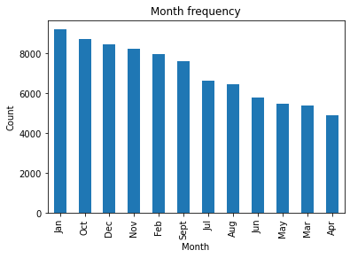

### Borrower APR across rating and term

from the chart,we can see that there is decrease in the the borrower APR with the increase of borrow term for people with HR-C raings. But for people with B-AA ratings, they is the APR increase with the increase of borrow term.

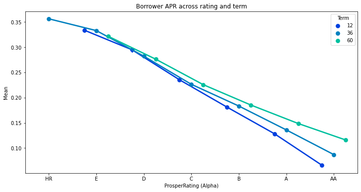

### Correlation Heat Map

The loan original amount is positively correlated with the stated monthly income with a coefficient of 0.18,The correlation coefficient of borrower APR and loan original amount is -0.426

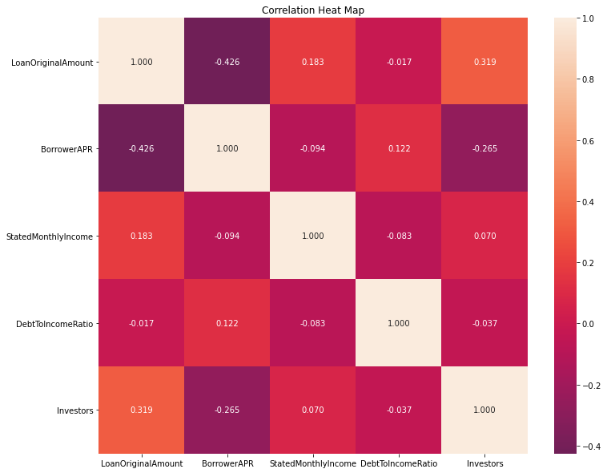